# Katoličke teme u digitalnom prostoru

Godišnji pregled 2025.

# Sažetak

Ovo je prvi godišnji pregled DigiKata. Opisuje što se tijekom 2025. godine u hrvatskom digitalnom prostoru objavljivalo o katoličkim temama, koliko toga ima, tko to objavljuje, o čemu se govori i kojim tonom.

- Zabilježili smo **124 346 objava** o katoličkim temama u 2025. godini.
- Web je i dalje glavno mjesto rasprave i nosi **54,0 %** godišnjeg volumena.
- Objave dolaze iz **5 814 različitih izvora**, što je vrlo raspršen prostor.
- Ipak, samo **56 izvora** čini polovicu cjelogodišnjeg volumena.
- Godinu vodi duhovnost i liturgija: vodeća je tema u **50,4 % objava** u tematskom uzorku.
- Zlostavljanje i kriza povjerenja čine **0,9 %** svih tematskih spominjanja.
- Na dan smrti pape Franje zabilježili smo **2 825 objava**, najviše u cijeloj godini.
- Pretežno pozitivan rječnik koristi **90,4 % objava** u tonskom uzorku.
- Sekularni izvori nose **1,36×** više riječi sukoba od konfesionalnih.
- Unutar istoga toka prikupljanja web je objavio **+11,5 %** više nego godinu prije.

Svaka brojka u ovom izvještaju izračunana je iz baze i može se ponoviti. Nijedna nije upisana rukom. Gdje mjera još ne postoji, to je izrečeno, a ne popunjeno procjenom.

**NoteŠto ovaj izvještaj jest, a što nije**

Mjerimo **zabilježeni** digitalni prostor: objave koje je projekt prikupio i koje su prošle pravilo uključivanja. To nije cijeli internet i nije mjera vjere u Hrvatskoj. Kad kažemo „objava”, mislimo na jedan zapis u bazi — članak, objavu na mreži, video ili komentar. Kad kažemo „izvor”, mislimo na medij ili račun s kojega je objava došla, a ne na pojedinu osobu.

#### Deset brojeva 2025. godine

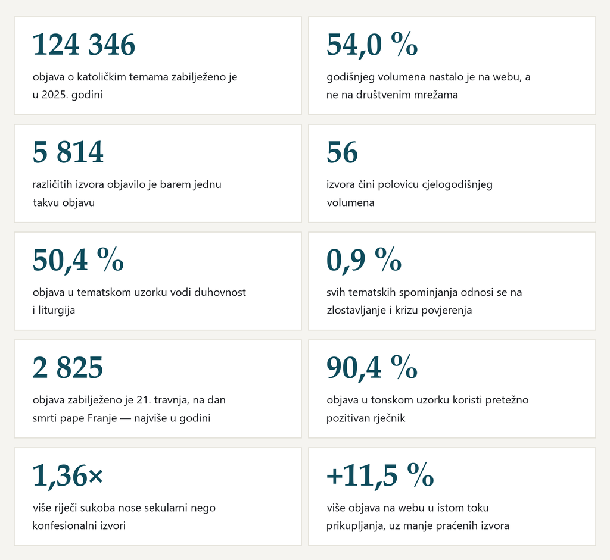

> Svaki je broj izračunan iz korpusa; nijedan nije upisan rukom. · Izvor: DigiKat, službeni korpus. Kalendarska 2025.

# Executive summary

This is the first DigiKat annual review. It describes what the Croatian digital space published on Catholic themes during 2025: how much of it there is, who publishes it, what it is about and in what tone.

- We recorded **124,346 posts** on Catholic themes during 2025.
- The web remains the main venue and carries **54.0%** of annual volume.
- The posts come from **5,814 distinct sources**, a highly dispersed space.
- Even so, just **56 sources** account for half of the year’s volume.
- Spirituality and liturgy lead the year, dominant in **50.4% of posts** in the theme sample.
- Abuse and the crisis of trust account for **0.9%** of all dictionary mentions.
- On the day Pope Francis died we recorded **2,825 posts**, the most in the whole year.
- Predominantly positive vocabulary appears in **90.4% of posts** in the tone sample.
- Secular sources carry **1.36×** as many conflict words as confessional ones.
- Within the same collection stream, the web carried **+11.5%** more than a year earlier.

Every figure in this report is computed from the database and can be reproduced. None is typed by hand. Where a measure does not yet exist, the report says so instead of filling the gap with an estimate.

# Kako čitamo ove brojke

Baza sadrži **413 985 objava** prikupljenih od 1. siječnja 2021. do 11. lipnja 2026. Objava ulazi u bazu kad u prvih tri tisuće znakova teksta zadovolji popis od 119 religijskih pojmova i kad je model drugoga prolaza ocijeni iznad praga 0,70. Isto pravilo vrijedi za cijelo razdoblje. Ručna provjera uzorka pokazuje da je oko **84,5 %** objava u bazi doista o katoličkim temama.

Za 2025. godinu to je **124 346 objava**. Njih smo brojili na **351 dana**: prikupljanje je stajalo od 1. rujna 2025. do 14. rujna 2025., dakle 14 dana. Prema susjednim tjednima procjenjujemo da u tom prekidu nedostaje oko 3 948 objava. Taj je prekid vidljivo označen na svim prikazima kroz godinu.

**NoteZašto ne uspoređujemo 2025. s ranijim godinama**

Način prikupljanja promijenio se sredinom 2024. godine. Zbog toga rast ili pad broja objava preko te granice ne govori o javnoj raspravi, nego o instrumentu kojim je mjerimo. Jedina usporedba koju ovaj izvještaj izvodi ostaje **unutar istoga toka prikupljanja**: druga polovica 2024. prema drugoj polovici 2025. Iz obiju polovica uklonili smo iste kalendarske dane prekida, pa se uspoređuje jednak broj dana.

Dva sloja ovoga izvještaja — tema i ton — računaju se iz uzorka, a ne iz cijele baze. Tematski sloj čita **6 203 objava** (5,0 % godine), tonski **2 479 objava** (2,0 %). Uzorci su slučajni unutar svake kombinacije godine i platforme; iz njih su isključeni TikTok i tekstovi kraći od 101 znaka. Uz svaku takvu brojku stoji koliko je objava iza nje.

# Mapa ekosustava

## Koliki je prostor?

U 2025. godini zabilježili smo 124 346 objava o katoličkim temama. Više od polovice, 54,0 %, nastalo je na webu — na portalima i stranicama, a ne na društvenim mrežama. Facebook nosi 26,0 %, YouTube 14,9 %.

#### Web nosi više od polovice zabilježenih objava

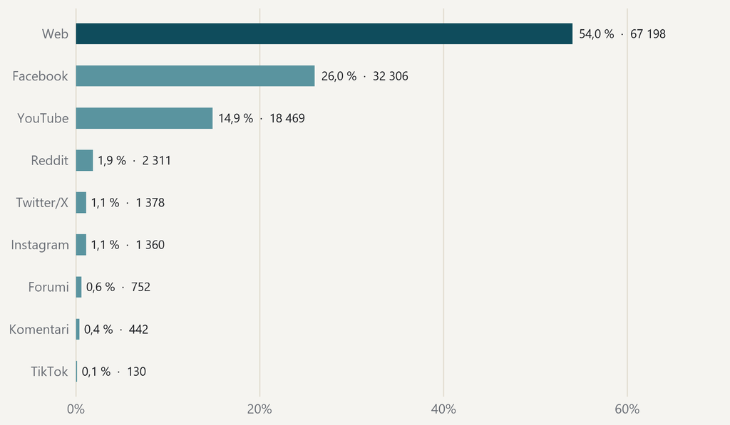

> Udio platforme u 124 346 objava iz 2025. godine, uz apsolutni broj. · Izvor: DigiKat, službeni korpus. Kalendarska 2025.

#### Gdje su objave nastale?

| Platforma | Objava | Udio | Interakcija | Doseg |
| --- | --- | --- | --- | --- |
| Web | 67 198 | 54,0 % | 4 493 667 | 121 037 110 |
| Facebook | 32 306 | 26,0 % | 4 467 362 | 398 595 788 |
| YouTube | 18 469 | 14,9 % | 3 366 728 | 80 862 905 |
| Reddit | 2 311 | 1,9 % | nije zabilježeno | nije zabilježeno |
| Twitter/X | 1 378 | 1,1 % | 26 308 | 5 201 689 |
| Instagram | 1 360 | 1,1 % | 470 690 | 4 006 437 |
| Forumi | 752 | 0,6 % | nije zabilježeno | nije zabilježeno |
| Komentari | 442 | 0,4 % | nije zabilježeno | nije zabilježeno |
| TikTok | 130 | 0,1 % | 145 624 | 2 344 773 |

> Izvor: DigiKat, službeni korpus. „Nije zabilježeno” znači da mjerenje na toj platformi ne postoji u prikupljenim podacima — ne znači da interakcija ili dosega nije bilo. Objava, interakcija i doseg tri su različita pitanja i ne zbrajaju se.

Broj objava i doseg nisu ista stvar. Facebook čini četvrtinu objava, ali 65,1 % zabilježenoga dosega. Web piše više, mreže dosežu šire. Za dio platformi doseg i interakcije uopće nisu prikupljeni; ondje piše da mjere nema, a ne nula.

#### Travanj nosi vrh godine, a rujanski pad je prekid u prikupljanju

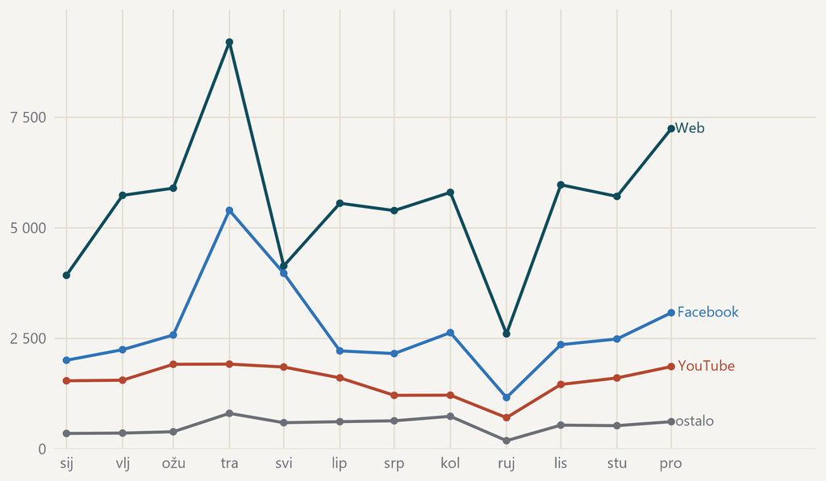

> Mjesečni broj objava, tri najveće platforme i zbroj svih ostalih. · Izvor: DigiKat, službeni korpus. Kalendarska 2025. Rujan je nepotpun: prikupljanje je stajalo prvih četrnaest dana. Nazivi platformi stoje uz krivulju, pa se čita i bez boje.

## Tko vodi?

Objave dolaze iz **5 814 različitih izvora**. To je vrlo raspršen prostor, ali raspršenost vara: prvih deset izvora nosi 22,5 % godine, a **56 izvora** čini njezinu polovicu. Ostatak je dugi rep u kojem tisuće izvora godišnje objave po nekoliko puta.

#### Malo izvora nosi mnogo, ali rep je vrlo dug

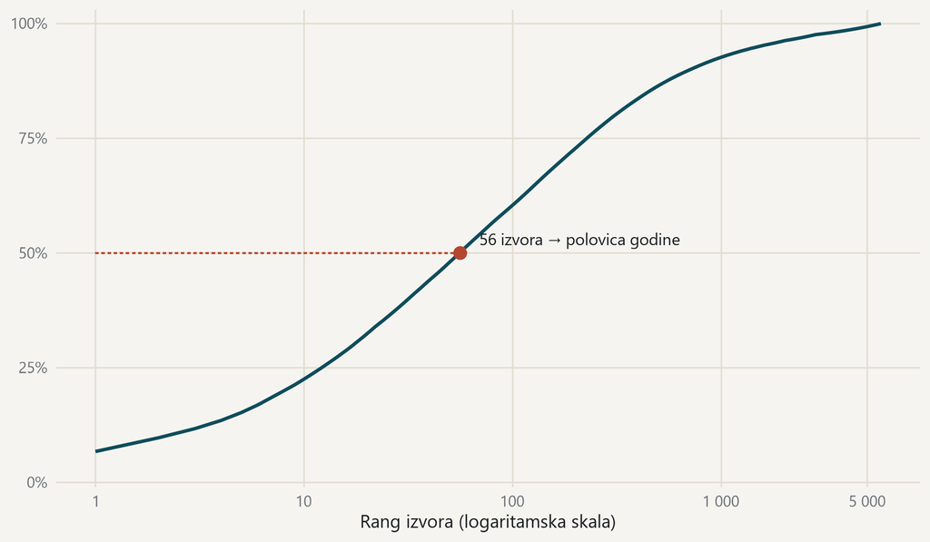

> Kumulativni udio godišnjeg volumena po rangu izvora; ukupno 5 814 izvora. · Izvor: DigiKat, službeni korpus. Kalendarska 2025.

#### Koje institucije najviše objavljuju?

| # | Izvor | Objava | Udio godine | Oznaka |
| --- | --- | --- | --- | --- |
| 1 | hkm.hr | 8 397 | 6,75 % | konfesionalni |
| 2 | Bitno.net | 3 695 | 2,97 % | konfesionalni |
| 3 | Net.hr | 2 207 | 1,77 % | sekularni |
| 4 | Laudato | 2 135 | 1,72 % | konfesionalni |
| 5 | novizivot.net | 2 078 | 1,67 % | konfesionalni |
| 6 | VJERA U NAMA † | 2 047 | 1,65 % | konfesionalni |
| 7 | pulherissimus | 1 775 | 1,43 % | sekularni |
| 8 | Slobodna Dalmacija | 1 583 | 1,27 % | sekularni |
| 9 | Večernji list | 1 491 | 1,20 % | sekularni |
| 10 | Index | 1 392 | 1,12 % | sekularni |
| 11 | Radio Marija Hrvatska | 1 345 | 1,08 % | konfesionalni |
| 12 | Laudato | 1 139 | 0,92 % | konfesionalni |

> Izvor: DigiKat, službeni korpus, uz PI-jev popis izvora. Imenujemo samo institucijske medije koje je urednik odobrio za objavu i koji su u godini imali najmanje pet objava; pojedinačni računi ne imenuju se nikada. Redoslijed mjeri količinu, ne kvalitetu ni utjecaj. Strelice promjene doći će s drugom edicijom — ovo je prva usporediva godina.

Imenujemo samo one izvore koje je urednik potvrdio kao institucijske medije. Takvih je 51 i zajedno nose 35,9 % godine. Ostali izvori postoje u brojkama, ali se ne imenuju dok popis ne bude ratificiran.

*Raščlamba po biskupijama, redovničkim zajednicama ili pojedinim naslovima dostupna je kao naručena analiza.*

Za dio izvora znamo i uređivački identitet. Uredničke oznake pokrivaju 34,5 % godišnjeg volumena; unutar toga označenog dijela konfesionalni izvori nose 62,8 % objava. Oznake su prijedlog, a ne konačna klasifikacija, pa ovu brojku čitajte kao smjer, ne kao strukturu medijskog prostora.

#### Kako su akteri raspoređeni po interakcijama i dosegu?

| Skupina | Aktera | Udio |
| --- | --- | --- |
| Visoke interakcije i visok doseg | 396 | 45,3 % |
| Visoke interakcije, niži doseg | 44 | 5,0 % |
| Niže interakcije, visok doseg | 44 | 5,0 % |
| Niže interakcije i niži doseg | 391 | 44,7 % |

> Izvor: DigiKat, službeni korpus. Skupine nastaju podjelom po medijanu interakcija i medijanu dosega unutar svake platforme, i to samo za platforme koje te dvije mjere doista bilježe. Aktera mora imati barem dvanaest objava u godini. Skupine su opisne, ne ocjene.

Skupine u toj tablici opisuju odnos interakcija i dosega, a ne kvalitetu ili utjecaj. Ovogodišnji raspored objavljujemo; kretanje između skupina ne objavljujemo, jer bi za to referentne vrijednosti morale biti zamrznute unaprijed. Inače bi promjena skupa aktera izgledala kao promjena uloga.

## Gdje se razgovor seli?

Unutar istoga toka prikupljanja, u drugoj polovici godine, web je objavio +11,5 % više nego godinu prije — a broj praćenih web-izvora u istom je razdoblju −7,2 %. Rast dakle ne dolazi od šireg praćenja. Facebook je porastao +86,4 %, ali je ondje i broj praćenih izvora skočio +33,1 %, pa je dio toga rasta proširenje mjerenja.

#### Web raste iako pratimo manje izvora nego godinu prije

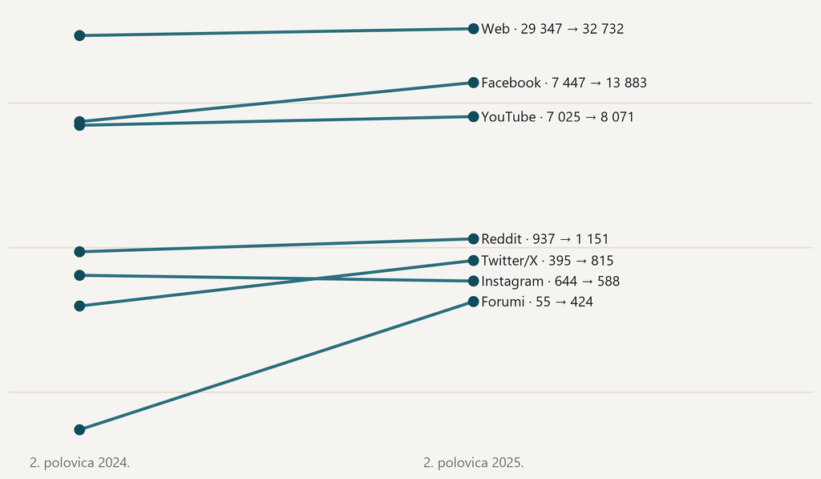

> Objave u drugoj polovici godine, unutar toka prikupljanja koji teče od srpnja 2024.; logaritamska skala. · Izvor: DigiKat, službeni korpus, tok post2024. Usporedba ne prelazi prijelom u prikupljanju iz 2024., a iz obiju polovica uklonjeni su isti kalendarski dani prekida.

#### Što se promijenilo unutar istoga toka prikupljanja?

| Platforma | 2. polovica 2024. | 2. polovica 2025. | Objave | Izvori |
| --- | --- | --- | --- | --- |
| Web | 29 347 | 32 732 | +11,5 % | −7,2 % |
| Facebook | 7 447 | 13 883 | +86,4 % | +33,1 % |
| YouTube | 7 025 | 8 071 | +14,9 % | +10,0 % |
| Reddit | 937 | 1 151 | +22,8 % | +27,1 % |
| Twitter/X | 395 | 815 | +106,3 % | +80,6 % |
| Instagram | 644 | 588 | −8,7 % | −4,3 % |
| Forumi | 55 | 424 | +670,9 % | +66,7 % |

> Izvor: DigiKat, službeni korpus, tok prikupljanja koji teče od srpnja 2024. Zadnji stupac pokazuje mijenja li se broj praćenih izvora: kad volumen i broj izvora rastu zajedno, vjerojatnije je da se proširilo praćenje nego sama rasprava.

**TipPitanja koja podaci otvaraju**

- Raste li web zato što isti izvori objavljuju više, ili zato što se pojavljuju novi naslovi?
- Prati li rast Facebooka i rast publike, ili samo rast broja stranica?
- Koliko se objava istoga izvora pojavljuje na više platformi odjednom?

# Tematske struje

## O čemu se govorilo?

Godinu vodi ono što Crkva radi svaki tjedan. Duhovnost i liturgija — mise, blagdani, sakramenti, molitva — vodeća je tema u **50,4 % objava** u tematskom uzorku i nosi 33,6 % svih rječničkih spominjanja. Slijede crkveno upravljanje i struktura, pa bioetičke i kulturne teme.

#### Godinu vodi ono što Crkva radi svaki tjedan

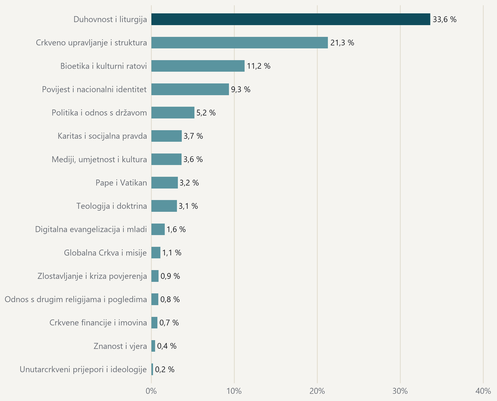

> Udio svih rječničkih spominjanja po kategoriji; prikazano je svih šesnaest kategorija. · Izvor: DigiKat, 6 203 objava iz korpusa za 2025. u tematskom uzorku (5,0 posto korpusne godine; TikTok i tekstovi kraći od 101 znaka nisu obuhvaćeni).

#### O čemu se govorilo?

| Tema | Spominjanja | Udio spominjanja | Vodeća tema objave |
| --- | --- | --- | --- |
| Duhovnost i liturgija | 47 077 | 33,6 % | 50,4 % |
| Crkveno upravljanje i struktura | 29 771 | 21,3 % | 23,5 % |
| Bioetika i kulturni ratovi | 15 750 | 11,2 % | 5,6 % |
| Povijest i nacionalni identitet | 13 090 | 9,3 % | 4,3 % |
| Politika i odnos s državom | 7 275 | 5,2 % | 3,3 % |
| Karitas i socijalna pravda | 5 131 | 3,7 % | 1,5 % |
| Mediji, umjetnost i kultura | 5 098 | 3,6 % | 3,0 % |
| Pape i Vatikan | 4 458 | 3,2 % | 4,6 % |
| Teologija i doktrina | 4 304 | 3,1 % | 1,6 % |
| Digitalna evangelizacija i mladi | 2 254 | 1,6 % | 0,6 % |
| Globalna Crkva i misije | 1 525 | 1,1 % | 0,2 % |
| Zlostavljanje i kriza povjerenja | 1 217 | 0,9 % | 0,1 % |
| Odnos s drugim religijama i pogledima | 1 174 | 0,8 % | 0,5 % |
| Crkvene financije i imovina | 1 003 | 0,7 % | 0,1 % |
| Znanost i vjera | 614 | 0,4 % | 0,1 % |
| Unutarcrkveni prijepori i ideologije | 274 | 0,2 % | 0,0 % |

> Izvor: DigiKat, tematski uzorak korpusa za 2025. Dva stupca odgovaraju na dva pitanja. „Udio spominjanja” dijeli sva rječnička pogotka među kategorijama, pa jedna objava može pridonijeti većem broju tema. „Vodeća tema objave” svakoj objavi pripisuje jednu, najjaču kategoriju, pa se taj stupac zbraja na sto posto zajedno s objavama bez ijednog pogotka (0,6 %).

**ImportantMit i podaci**

**Mit:** o Crkvi se u medijima piše uglavnom kad izbije skandal ili sukob.

**Podaci:** zlostavljanje i kriza povjerenja čine 0,9 % svih tematskih spominjanja, a unutarcrkveni prijepori 0,2 %. Četiri dana koja u godini najviše odudaraju od uobičajenog ritma redom su liturgijski ili papinski. To ne znači da su takve teme nevažne ni da ih mediji dobro pokrivaju — znači da u zabilježenom volumenu one nisu ono što godinu čini velikom.

# Atmosfera diskursa

## Kakvim se tonom govori?

Tonski rezultat mjeri rječnik objave na ljestvici od −1 do +1: koliko riječi iz nje nosi pozitivan, a koliko negativan predznak u rječniku sentimenta. On ne mjeri stav autora, istinitost tvrdnje ni namjeru. U tonskom uzorku prosjek je 0,61, a pretežno pozitivan rječnik koristi 90,4 % objava. Razlog je dobrim dijelom sam predmet: obavijesti o misi, blagoslovu i slavlju nose pozitivne riječi.

#### Nijedna tema godine nije u prosjeku negativna

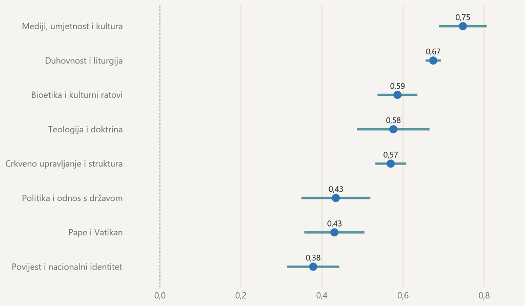

> Prosječan tonski rezultat po vodećoj temi objave, od −1 do +1; kategorije s najmanje 30 objava. · Izvor: DigiKat, 2 479 objava iz korpusa za 2025. u tonskom uzorku (2,0 posto korpusne godine). Crte prikazuju 95-postotni interval.

#### Kojim se tonom govori o vodećim temama?

| Tema | Objava | Tonski rezultat | Riječi sukoba |
| --- | --- | --- | --- |
| Mediji, umjetnost i kultura | 69 | 0,75 | 63 |
| Duhovnost i liturgija | 1 270 | 0,67 | 71 |
| Bioetika i kulturni ratovi | 133 | 0,59 | 98 |
| Teologija i doktrina | 41 | 0,58 | 73 |
| Crkveno upravljanje i struktura | 581 | 0,57 | 76 |
| Politika i odnos s državom | 76 | 0,43 | 86 |
| Pape i Vatikan | 119 | 0,43 | 94 |
| Povijest i nacionalni identitet | 115 | 0,38 | 95 |

> Izvor: DigiKat, tonski uzorak korpusa za 2025. Tonski rezultat ide od −1 do +1 i mjeri rječnik, a ne stav autora ni istinitost tvrdnje. „Riječi sukoba” broje pojmove sukoba, ljutnje i straha na tisuću riječi. Prikazane su samo teme s najmanje trideset objava u uzorku.

Uz ton pratimo i koliko se često koriste riječi sukoba — pojmovi ljutnje, straha, napada, podjele i skandala. Prosjek godine je 76 takvih riječi na tisuću.

Razlika između konfesionalnih i sekularnih izvora vidljiva je i mjerljiva. Konfesionalni izvori nose 70 riječi sukoba na tisuću, sekularni 95 — dakle 1,36× više. Intervali pouzdanosti tih dviju vrijednosti ne preklapaju se. Razlika opisuje rječnik, ne pristranost: sekularni medij o Crkvi češće piše kad je tema spor, a konfesionalni pokriva i redovni život zajednice.

#### Sekularni izvori pišu o istoj temi oštrijim rječnikom

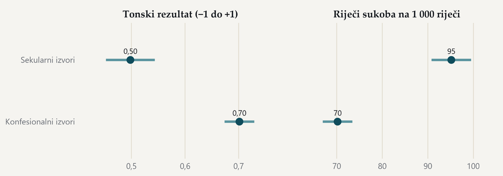

> Konfesionalni (530 objava) i sekularni izvori (321 objava) u tonskom uzorku. · Izvor: DigiKat, 2 479 objava iz korpusa za 2025. u tonskom uzorku (2,0 posto korpusne godine). Crte prikazuju 95-postotni interval. Uredničke oznake izvora imaju status prijedloga, pa je usporedba indikativna.

**TipPitanja koja podaci otvaraju**

- Ostaje li razlika u rječniku i kad se usporede objave o istom događaju istoga dana?
- Kako se ton mijenja unutar jednog događajnog luka, od prve vijesti do komentara?
- Razlikuju li se po tonu nacionalni i lokalni mediji jednako kao konfesionalni i sekularni?

# Fokus na događaje

## Što je obilježilo godinu?

Godina ima jedan jasan vrh. Na dan **21. travnja 2025.** zabilježili smo **2 825 objava**, 12,0 standardnih devijacija iznad prosječnog dana. Cijeli luk od 20. 4. 2025. do 23. 4. 2025. nosi 6 484 objava.

#### Godina ima jedan vrh, i on nije bio sporan

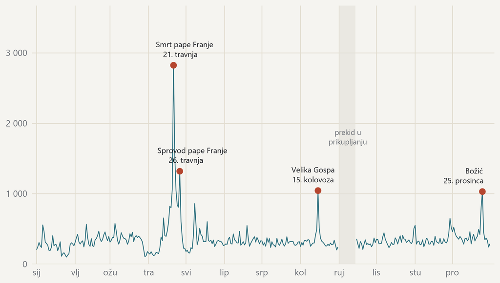

> Broj objava po danu, 351 dana s prikupljanjem; označeni su dani iznad tri standardne devijacije. · Izvor: DigiKat, službeni korpus. Kalendarska 2025. Prag za vrhunac postavljen je prije pregleda podataka, a prosjek i raspršenost računaju se samo nad danima s prikupljanjem.

#### Koji su dani odudarali od godišnjeg ritma?

| Datum | Događaj | Objava | Odstupanje | Dana u luku |
| --- | --- | --- | --- | --- |
| 21. 4. 2025. | Smrt pape Franje | 2 825 | 12,0 sd | 4 |
| 26. 4. 2025. | Sprovod pape Franje | 1 320 | 4,7 sd | 1 |
| 15. 8. 2025. | Velika Gospa | 1 045 | 3,4 sd | 1 |
| 25. 12. 2025. | Božić | 1 031 | 3,3 sd | 1 |

> Izvor: DigiKat, službeni korpus, svi dani u godini. Odstupanje je udaljenost od prosječnog dana u godini, izražena u standardnim devijacijama; prag od tri postavljen je prije pregleda podataka. Nazivi dolaze iz javnog kalendara i potvrđeni su tematskim sastavom tih dana — vrh sam po sebi pokazuje datum, ne uzrok.

**NoteMoment godine: smrt i sprovod pape Franje**

Papa Franjo umro je 21. travnja 2025. godine, na Uskrsni ponedjeljak, a sprovod je održan 26. travnja. Oba su datuma u našim podacima među danima koji najjače odudaraju od godišnjeg ritma. Nazive smo uzeli iz javnog kalendara i provjerili tematskim sastavom tih dana: u uzorku od 21. do 23. travnja vodeće su kategorije duhovnost i liturgija te crkveno upravljanje, a kategorija „Pape i Vatikan” raste na svoj godišnji vrhunac.

Vrh u podacima pokazuje **datum**, ne uzrok. Zato uz svaki naziv u ovom izvještaju stoji vanjska potvrda; bez nje datum ostaje samo datum.

Preostala tri vrhunca su Velika Gospa i Božić, dakle blagdani koji se ponavljaju svake godine, te drugi papinski dan. Godina nema nijedan vrhunac koji bi nastao iz spora.

# Posebno poglavlje: socijalni nauk i gospodarstvo

Svaka edicija donosi jedno dovršeno istraživanje, odvojeno od redovnih pokazatelja. Ove godine to je studija o tome koji dijelovi socijalnoga nauka Crkve ulaze u digitalnu javnu raspravu o gospodarstvu.

Studija je pretražila 108 966 objava u kojima se religijski i gospodarski govor susreću, a zatim ručno provjerila uzorak da bi izmjerila koliko je tih susreta stvarno. Nakon te korekcije doktrinarni pojmovi — dostojanstvo rada, opcija za siromašne, supsidijarnost, opće dobro — pojavljuju se u 3,73 parova objave i gospodarske teme.

#### Što je pokazala studija o socijalnom nauku i gospodarstvu?

| Mjera | Vrijednost |
| --- | --- |
| Objave u kojima se religijski i gospodarski govor susreću (sirovi nalaz detektora) | 108 966 |
| Objave s izrazom socijalnoga nauka uz gospodarski pojam | 1 198 |
| Ispravljena procjena udjela doktrinarnih parova (%) | 3,73 |
| Udio konfesionalnih izvora među razvrstanim doktrinarnim objavama (%) | 67,02 |

> Izvor: generirani rezultati studije `moral-economy`. Vrijednosti pokrivaju cijelo razdoblje te studije, a ne izvještajnu godinu, i ne ulaze u godišnje pokazatelje. Prva dva reda su ono što je detektor pronašao; ispravljena procjena dijeli taj nalaz preciznošću koju je pokazala ručna provjera uzorka.

Zaključak studije je da Crkva u gospodarskoj raspravi govori rijetko, ali kad govori, govori razmjerno dosljedno vlastitom rječniku. Vrijednosti pokrivaju razdoblje te studije i ne ulaze u godišnje pokazatelje.

**TipPrimjer dubinske analize**

Ovako izgleda naručena analiza jednog događaja. Za travanjski luk oko smrti pape Franje ona bi sadržavala: dnevnu krivulju po platformama i izvorima; usporedbu prvih dvadeset četiri sata s ostatkom luka; tematski i tonski profil po danu; popis izvora koji su prvi objavili i onih koji su prenosili; mjeru koliko je dugo tema držala pažnju nakon vrhunca; te usporedbu s ekvivalentnim lukom u drugom mediju ili drugoj godini. Opseg, razdoblje i rezove dogovaramo unaprijed.

# Što još ne mjerimo

Ovaj izvještaj ima praznine i one su ovdje napisane, a ne prešućene.

**Kompozitni indeks godine.** Jedan zbirni broj koji bi sažeo cijelu godinu i pokazivao smjer bio bi koristan, ali on je mjera i mora proći postupak izmjene pokazatelja. Uvest ćemo ga tek kad referentna godina bude zamrznuta, da se ne bi mijenjao zajedno s onim što mjeri.

**Strelice promjene i „što smo rekli prošle godine”.** Ovo je prva edicija, pa nema s čime uspoređivati. Od sljedeće edicije uz svaku ljestvicu stoji promjena, a poseban dio izvještaja vraća se na brojke prethodne godine.

**Prijenos crkvenoga glasa.** Kad sekularni medij piše o temi o kojoj je crkveni izvor već govorio, koliko se često i koliko brzo u toj objavi pojavi crkveni okvir? To traži zaseban dizajn s uparivanjem i kontrolnim skupinama; izloženost nije prijenos.

**Publika.** Ne znamo kako publika te sadržaje susreće, koliko im vjeruje i što s njima radi. Za to je potrebna anketa s vlastitim uzorkom, instrumentom i etičkim odobrenjem.

**Uređivačke oznake izvora.** Pokrivaju 34,5 % godišnjeg volumena i imaju status prijedloga. Dok ne budu ratificirane, svaki podatak o konfesionalnom i sekularnom dijelu ostaje indikativan.

#### Što ova edicija mjeri, a što još ne?

| Oznaka | Pokazatelj | Status |
| --- | --- | --- |
| AR01 | Volumen zabilježene rasprave | objavljeno |
| AR02 | Indikativni sastav izvora | indikativno |
| AR03 | Vodeći institucionalni akteri | objavljeno |
| AR04 | Raspored aktera po interakcijama i dosegu | objavljeno bez kretanja |
| AR05 | Referentne vrijednosti angažmana | objavljeno |
| AR06 | Tematski profil | objavljeno |
| AR07 | Ton i sukob | objavljeno |
| AR08 | Dani koji odudaraju | objavljeno |
| AR09 | Prijenos crkvenoga glasa | u pripremi |
| AR10 | Anketa publike | u pripremi |

> Puna definicija svakog pokazatelja, pravilo usporedivosti i povijest promjena nalaze se u dokumentu `INDICATORS.md`.

# Metodologija

**Baza.** 413 985 objava, od 1. siječnja 2021. do 11. lipnja 2026. Jedno pravilo uključivanja vrijedi za oba razdoblja prikupljanja: popis od 119 religijskih pojmova mora se javiti u prvih tri tisuće znakova teksta, a model drugoga prolaza mora objavu ocijeniti iznad 0,70. Ručno čitani uzorci daju procjenu točnosti od oko 84,5 %.

**Okvir.** Baza je tematska, ne izvorna: obuhvaća i konfesionalne i sekularne izvore, sve dok objava govori o katoličkim temama. Sadrži i regionalne, uključujući bosanskohercegovačke sadržaje. Zato ne opisuje „hrvatski internet”, nego ono što je projekt prikupio.

**Godina.** 124 346 objava na 351 dana s prikupljanjem. Prekid od 1. rujna 2025. do 14. rujna 2025. ostavljen je vidljiv i isključen iz svakog prosjeka; prosječan dan oko prekida nosio je 282 objava.

**Vrhunci.** Dan se izdvaja ako je tri ili više standardnih devijacija iznad prosjeka godine. Prag je postavljen prije nego što su podaci pregledani. Prosjek i raspršenost računaju se samo nad danima s prikupljanjem. Dani koji su međusobno udaljeni najviše dva dana pripadaju istom luku.

**Teme.** Zamrznuti rječnik od šesnaest kategorija. Za svaku objavu brojimo pogotke po kategoriji. „Udio spominjanja” dijeli sve pogotke, pa jedna objava može pridonijeti većem broju tema; „vodeća tema objave” svakoj objavi pripisuje jednu kategoriju. Rječnik prepoznaje riječi, ne značenje, i njegova preciznost po kategoriji još nije ručno provjerena.

**Ton.** Tonski rezultat računa se iz hrvatskih rječnika sentimenta na lemama, na ljestvici od −1 do +1. Riječi sukoba broje pojmove ljutnje, straha, gađenja i sukoba na tisuću riječi. Obje mjere opisuju rječnik objave.

**Uzorci.** Tematski i tonski sloj računaju se iz slučajnih uzoraka same baze, izvučenih zasebno unutar svake kombinacije godine i platforme. Uz svaku vrijednost stoji broj objava, a uz prosjeke i interval pouzdanosti.

**Imenovanje.** Imenuju se samo institucijski mediji koje je urednik odobrio i koji u godini imaju barem pet objava. Pojedinačni računi ne imenuju se nikada. Ćelije ispod praga se potiskuju.

**Ponovljivost.** Cjelovita definicija svakog pokazatelja, pravilo usporedivosti i povijest promjena nalaze se u dokumentu `INDICATORS.md`. Pregledani agregati objavljuju se uz izvještaj.

# Dodatak: ogledni profili institucijskih izvora

### hkm.hr

**Web · Visoke interakcije i visok doseg**

- Objava u 2025.: **8 397**
- Interakcija: **157 778**
- Interakcija po objavi: **18,8**, odnosno 0,35 medijana svoje skupine na istoj platformi

### VJERA U NAMA †

**Facebook · Visoke interakcije i visok doseg**

- Objava u 2025.: **2 047**
- Interakcija: **52 534**
- Interakcija po objavi: **25,7**, odnosno 0,22 medijana svoje skupine na istoj platformi

### pulherissimus

**YouTube · Visoke interakcije i visok doseg**

- Objava u 2025.: **1 775**
- Interakcija: **540 306**
- Interakcija po objavi: **304,4**, odnosno 1,55 medijana svoje skupine na istoj platformi

### Laudato

**Instagram · Visoke interakcije, niži doseg**

- Objava u 2025.: **30**
- Interakcija: **16 341**
- Interakcija po objavi: **544,7**, odnosno 1,00 medijana svoje skupine na istoj platformi

### dnevniavaz

**Instagram · Niže interakcije, visok doseg**

- Objava u 2025.: **28**
- Interakcija: **11 578**
- Interakcija po objavi: **413,5**, odnosno 1,00 medijana svoje skupine na istoj platformi

### Dnevnik.hr

**TikTok · Niže interakcije i niži doseg**

- Objava u 2025.: **13**
- Interakcija: **11 625**
- Interakcija po objavi: **894,2**, odnosno 1,00 medijana svoje skupine na istoj platformi

# Neovisnost, licencija i zahvale

**Urednik:** doc. dr. sc. Luka Šikić, Hrvatsko katoličko sveučilište.

Obuhvaćeni akteri nemaju nikakvu ulogu u odabiru pokazatelja, analizi, tumačenju ni odobravanju izvještaja. Prije objave održava se kratko informativno predstavljanje pod embargom; ono ne može promijeniti rezultat, osim ako se utvrdi provjerljiva činjenična pogreška.

Pregledani agregati i tekst izvještaja objavljuju se pod licencijom CC BY 4.0, ondje gdje to dopuštaju prava izvora. Redovi s tekstom objava, poveznice i identiteti pojedinaca nisu dio objavljenog paketa.

U pripremi analitičkog cjevovoda, nacrta i mehaničkih provjera korišten je Claude Code. Odgovornost za metodološke odluke, uredničke oznake i objavu ostaje na uredniku i istraživačkom timu.

Pitanja o podacima i metodi: **luka.sikic@unicath.hr** · Hrvatsko katoličko sveučilište, Ilica 242, Zagreb · [lusiki.github.io/DigiKat](https://lusiki.github.io/DigiKat/)

*Ova je edicija dovršena i mehanički provjerena; objava zahtijeva potpis urednika prema postupku iz uređivačke povelje.*